# eCrimex CCWG Data Stats

Arghya Mukherjee

15 June, 2021

# eCrimex Data

eCrimex curates cryptocurrency wallet data from different sources which are involved in scams and different crimes. The data is available for the research community on request also we will make it available on our github.

In this document, we summarise the data that is collected periodically and updated everyday. The R code used to create the summary statistics are available on clicking *code*.

#### R Libraries used

```r
#Required Libraries

suppressWarnings({
library(data.table)
library(ggplot2)
library(scales)
library(cowplot)
library(dplyr)
library(Polychrome)
library(kableExtra)})
options(scipen = 999)
```

#### Clean Data set

The timestamps provided by ecrimex are unix stamps. Hence, for visualization purposes, we convert the data into YYYY-MM-DD and then follow that up by creating a date variable with the first date of the the month (YYYY-MM-01). We then create a data frame with the count of reported date by month.

```r
ecrimex$timestamp <- as.Date(as.POSIXct(ecrimex$timestamp,origin="1970-01-01"))
ecrimex$modified <- as.Date(as.POSIXct(ecrimex$modified,origin="1970-01-01"))
ecrimex <- ecrimex[order(timestamp),]
ecrimex$year_mon <- format(ecrimex$timestamp,"%Y-%m-01")
ecrimex[,count_by_date:=.N,by=year_mon]
ecrimex_date <- ecrimex[,c(12,11)]
ecrimex_date <- unique(ecrimex_date)
ecrimex_date$year_mon <- as.Date(ecrimex_date$year_mon)
```

## Summary Stats

These section of the document will show the summary of all the data that we have collected and follow that up with some plots.

#### Code for Time Series plot showing addresses reported by Month

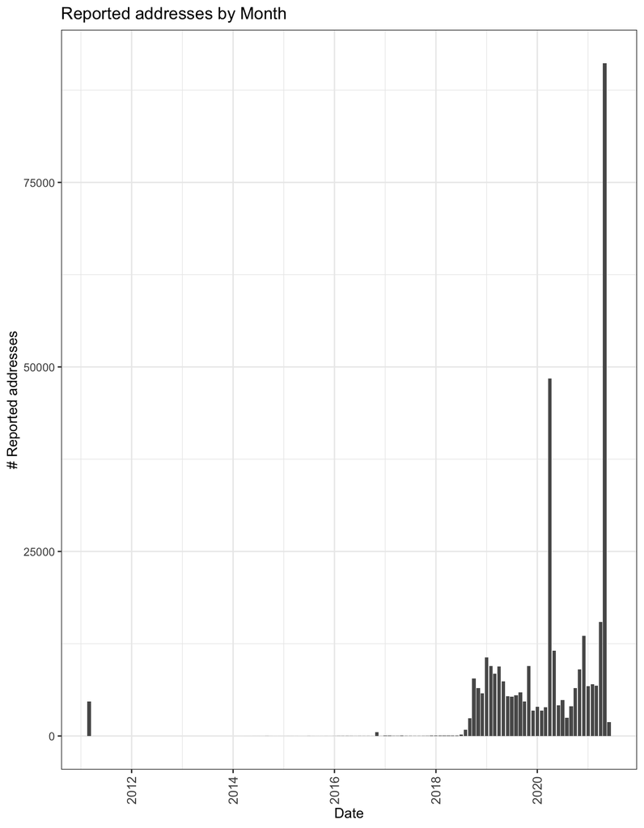

```r
# Code for Time Series plot showing addresses reported by Month
plot1 <- ggplot(ecrimex_date,aes(x=year_mon,y=count_by_date))+
  geom_bar(stat="identity")+theme_bw()+
  labs(x="Date",y="# Reported addresses")+
  ggtitle("Reported addresses by Month")+
  theme(axis.text.x = element_text(angle = 90, vjust = 0.5, hjust=1,size=10))
plot_grid(plot1)
```

#### Code to fix upload date

```r
ecrimex$year_mon_2 <- format(ecrimex$modified,"%Y-%m-01")
ecrimex[,count_by_date_2:=.N,by=year_mon_2]
ecrimex_date_2 <- ecrimex[,c(13,14)]
ecrimex_date_2 <- unique(ecrimex_date_2)
ecrimex_date_2 <- ecrimex_date_2[order(year_mon_2),]
```

#### Code for Time Series plot showing addresses posted by Month

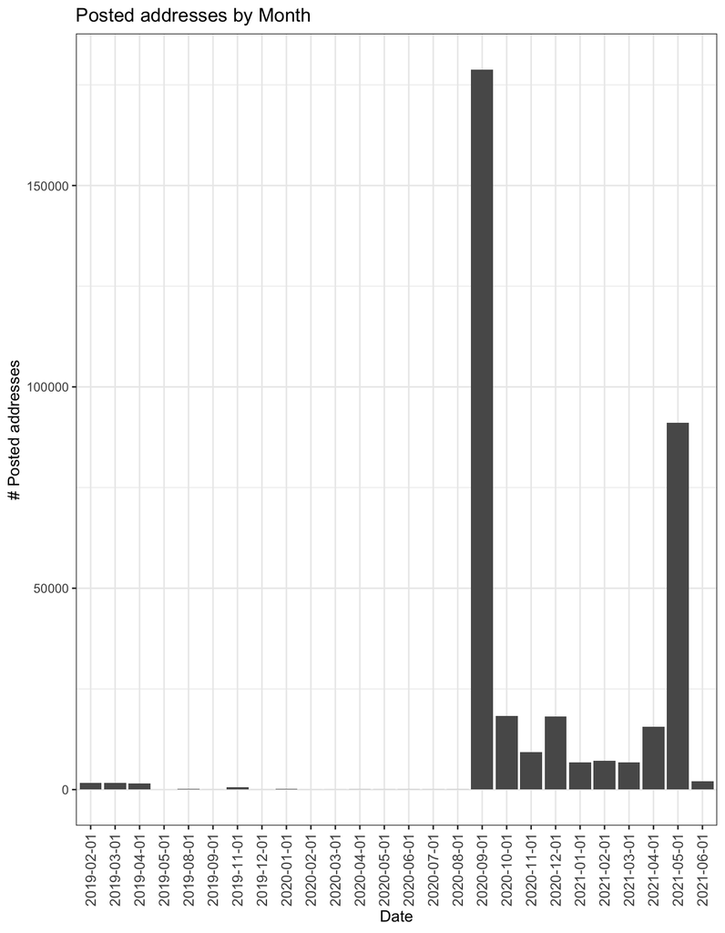

```r
# Code for Time Series plot showing addresses posted by Month
plot2 <- ggplot(ecrimex_date_2,aes(x=year_mon_2,y=count_by_date_2))+
  geom_bar(stat="identity")+theme_bw()+
  labs(x="Date",y="# Posted addresses")+
  ggtitle("Posted addresses by Month")+
  theme(axis.text.x = element_text(angle = 90, vjust = 0.5, hjust=1,size=10))

plot_grid(plot2)
```

The table below shows number of reported wallet addresses of different coin follwed by a pie chart of its their reporting

```r
# Number of times a coin appears on our data base.
coin_count<-df %>% count(currency)
coin_count <- data.table(coin_count)

colnames(coin_count) <- c("currency","coin_count")
coin_count %>% kbl() %>% kable_material(c("striped", "hover"))
```

| currency | coin_count |
| --- | --- |
| ADA | 12 |
| BCH | 184 |
| BNB | 8 |
| BTC | 345610 |
| DASH | 113 |
| DOGE | 66 |
| ETH | 12989 |
| LTC | 270 |
| NEO | 11 |
| TRX | 16 |
| XLM | 7 |
| XMR | 71 |
| XRP | 196 |
| XZC | 2 |
| ZEC | 7 |
| ZIL | 1 |

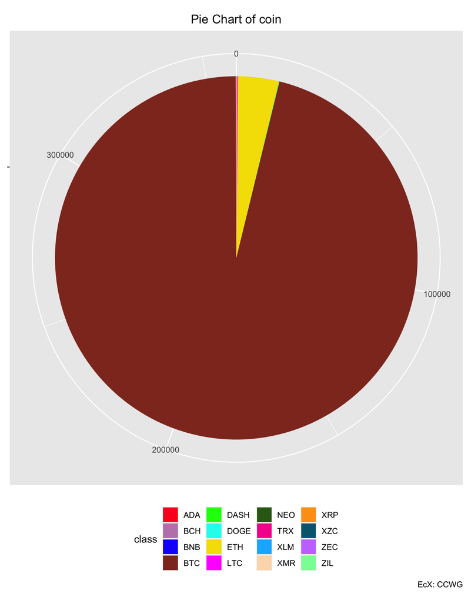

```r
#coin pie
coin_pie <- ggplot(coin_count,aes(x="",y=coin_count,fill=factor(currency)))+
  geom_bar(width=1,stat = "identity")+
  theme(axis.line = element_blank(),plot.title = element_text(hjust=0.5)) +
  labs(fill="class",x=NULL,y=NULL, title="Pie Chart of coin",caption="EcX: CCWG")+
  scale_fill_manual(values=as.vector(P80))+theme(legend.position="bottom")

coin_pie <- coin_pie + coord_polar(theta = "y",start=0)
coin_pie
```

The table below shows number of reporters of wallet addresses of different coin follwed by a pie chart of its contributor share

```r
# Number of times a submitter have posted data in our data base
submitter_count <-df %>% count(submitter)
submitter_count <- data.table(submitter_count)
#submitter_count$submitter[submitter_count$num_submitter <500] <- "Other"
colnames(submitter_count) <- c("submitter","num_submitted")

submitter_count %>% kbl() %>% kable_material(c("striped", "hover"))
```

| submitter | num_submitted |
| --- | --- |
| AIT | 554 |
| APWG | 331380 |
| CipherTrace | 4619 |
| concinnity | 10166 |
| Other | 3 |
| University of Ottawa | 12841 |

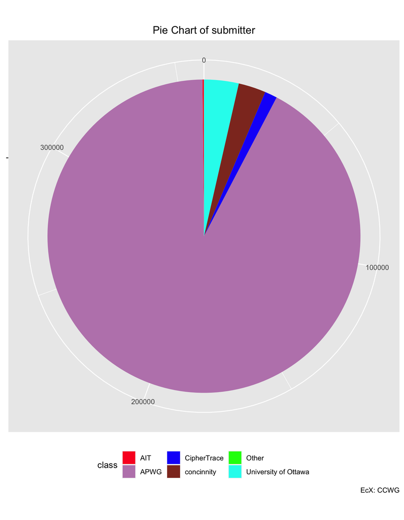

```r
# Pie chart for submitter
submitter_pie <- ggplot(submitter_count,aes(x="",y=num_submitted,fill=factor(submitter)))+
  geom_bar(width=1,stat = "identity")+
  theme(axis.line = element_blank(),plot.title = element_text(hjust=0.5)) +
  labs(fill="class",x=NULL,y=NULL, title="Pie Chart of submitter",caption="EcX: CCWG")+
  scale_fill_manual(values=as.vector(P80))+theme(legend.position="bottom")
submitter_pie <- submitter_pie + coord_polar(theta = "y",start=0)

plot_grid(submitter_pie)
```

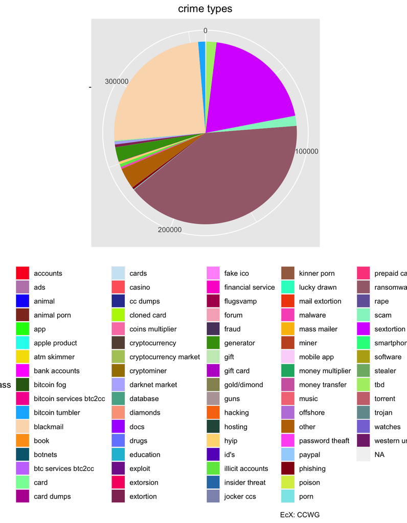

```r
#paletteEcoFin <- c("#9A5EA6", "#E5C473", "#B98B50", "61276D", "2E368F","D8C5E0", "0000FF", "800080")
crime_pie <- ggplot(crime_cat,aes(x="",y=n,fill=factor(crimeCategory)))+
  geom_bar(width=1,stat = "identity")+
  theme(axis.line = element_blank(),plot.title = element_text(hjust=0.5)) +
  labs(fill="class",x=NULL,y=NULL, title="crime types",caption="EcX: CCWG")+theme(legend.position="bottom")+
  scale_fill_manual(values=as.vector(P80))

crime_pie <- crime_pie + coord_polar(theta = "y",start=0)
plot_grid(crime_pie)
```

#Rscript -e “rmarkdown::render(‘summary_stats_markdown.Rmd’, clean=TRUE)”